# Module 7

Chris, Joe, Karim

11/27/2022

### Introduction

In this project we will be exploring the effect of length on muscle force generation and how fatigue impacts this force-length (FL) relationship. The question of how fatigue influences the FL relationship has been asked for a while in animal models. Many past studies have hope to analyze the impact of fatigue on the FL relationship in rats, with many finding that fatigue cause a sizable shift towards longer muscle length at which the maximal force occurs. Other studies, like that of MacNaughton and MacIntosh (2006) in 2006, found that this right-wards shift towards longer length at maximum force generation is overexaggerated, leading to some contention about the exact increase size of the shift. As a result of this uncertainty in the field, our study hopes to show another example of how the FL relationship is influence by fatigue in an attempt to provide more certainty around how sizable the shift actually is. In addition, our study hopes to provide more context on how fatigue impacts the FL relationship of the human upper limb specifically in humans, as the literature does not appear to have much information in this area. This study will prove to be important as we seek to gain a better understanding of our muscles and how fatigue impacts the amount of actin-myosin overlap, and thereby the isometric force created, at each point in our contraction.

In order to assess the force length relationship of the upper human limb in our study, we will be making the assumption that the force we measure at our hand as the muscle produces isometric force at various lengths is a reasonable reflection of the FL relationship government force at the fiber level, based on previous work by Rassier, MacIntosh, and Herzog (1999). Additionally, because the human upper limb is essentially a 3rd order lever (muscles on either side of the arm span the elbow joint), we will be using the mechanical advantage equation to predict the amount of output force created by the human upper limb based on the output force present on the human palm at the point of exertion. Our investigation will be broken up into three parts. First, we will produce the isometric force-angle curves for the human forearm flexors undertaking the maximum voluntary contractions (MVCs). Second, we will compare the angle at which the maximum isometric force occurs between non-fatigues and eccentrically fatigues forearm flexors. Third, we will investigate the underlying mechanisms resulting in a shift of the angle at which maximum isometric force occurs after eccentric fatigue.

### Methods

#### Data Analysis

Before starting our analysis, we normalized the force data for each recording to ensure that any unit discrepancies between recordings did not impact our results. We did this by finding the maximum force for each recording for each individual and dividing the other force values in the recording by the maximum value (now forces are on a scale of 0-1, with a value of 1 representing the maximum force). After we normalized our data, we compiled it and used a 4th order polynomial model to produce isometric force-angle curves for each Subject (fatigued and non-fatigued). Next, we used the fatigued and non-fatigued curve for each Subject to detect shifts in the maximum force with respect to angle. Finally, we used script written in R to calculate the mean shift between fatigued and non-fatigued across all trials.

### Results

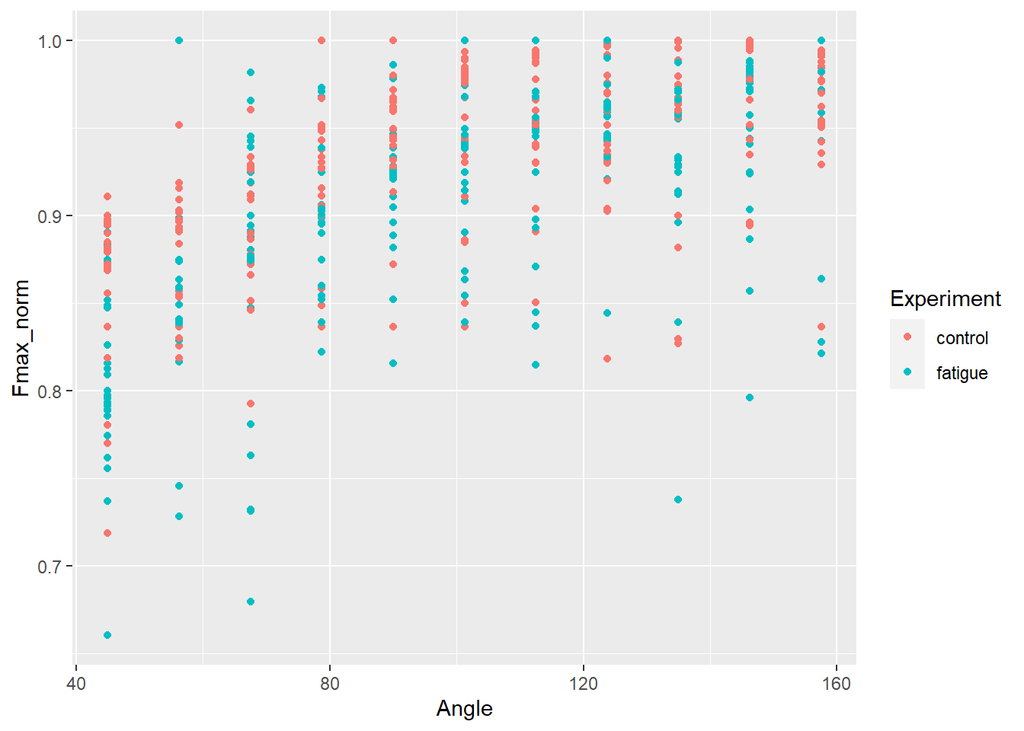

Figure 1. Normalized Fmax Values vs. Angle

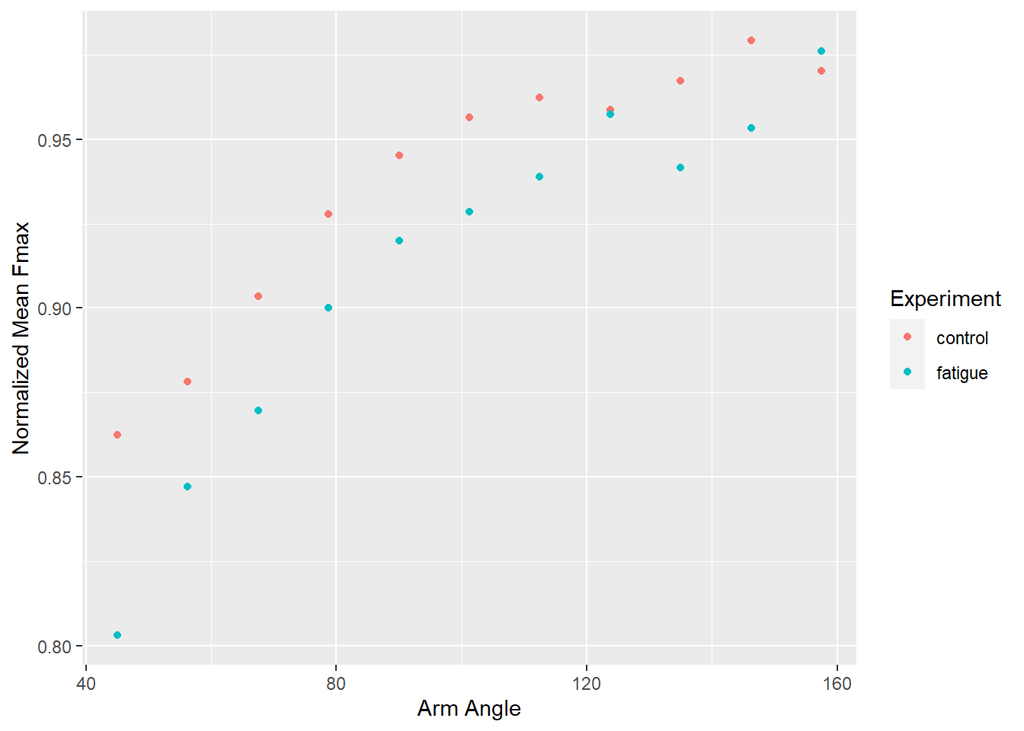

Figure 2. Mean Normalized Fmax vs. Angle

Both figures depict the data collected with force plotted against the forearm angle where force was expressed as a ratio of the maximum value for each subject. The figures depict a larger angle where maximal force was observed for the fatigued trials.

Table 1. Anova for Theta Max

|  | Df | Sum Sq | Mean Sq | F value | Pr(>F) |
| --- | --- | --- | --- | --- | --- |
| Experiment | 1 | 825.9698 | 825.9698 | 4.023465 | 0.0499877 |
| Residuals | 53 | 10880.2727 | 205.2882 | NA | NA |

Table 1 depicts the significance in the difference between the theta max in control and fatigue trials.

Table 2. Mean and SEM Values for Theta Max

| mean.shift | se.shift |
| --- | --- |
| 8.358358 | 4.25493 |

### Discussion

The collected data demonstrates a shift in the peak force relationship towards larger elbow-forearm angles. This finding can be visualized in figure 2. above, where the fatigued muscle (in blue) achieves a maximal value further to the right of the control. The average shift in the maximal angle of force, or theta max, was to an angle 8.36° larger. This conclusion coincides with prior research highlighted by MacNaughton and MacIntosh (2006). There does appear to be some discrepancy within the data, as the force reaches a local maximum around 112° for the control, but then climbs higher at roughly 130°. Theoretically, this phenomenon should not occur, as force should peak at an intermediate length. The observation of a lone peak between around 110° was expected, but not observed. The increase in force at higher angles was likely caused by the activation of chest and shoulder fibers as the arm straightened. The involvement of chest and shoulder muscles was unavoidable, as the participants had to pull vertically up to record force output. This direction of force output would encourage the use of additional muscle groups, explaining why the force did not peak at the expected range. In future trials, the experiment should be performed against a horizontal surface to isolate the bicep and observe an expected peak. Therefore, the local maximum observed at around 112° for the control and 125° for the experimental likely reflect the true peak for the bicep alone. Regardless of the involvement of other muscles, the maximal force produced when fatigued was shown to take place at greater angles.

### Author Contributions

Karim: Worked on the discussion and results.

Chris: Worked on the code and graphs.

Joe: Worked on the graphs, intro, and methods.

### References

MacNaughton, MB, and BR MacIntosh. 2006. “Reports of the Length Dependence of Fatigue Are Greatly Exaggerated.” *Journal of Applied Physiology* 101 (1): 23–29.

Rassier, Dilson E, BR MacIntosh, and W Herzog. 1999. “Length Dependence of Active Force Production in Skeletal Muscle.” *Journal of Applied Physiology* 86 (5): 1445–57.